# Comparing Motion Correction of Open-Source DWI Preprocessing Pipelines

# Preamble

I’m using the [Masivar](https://openneuro.org/datasets/ds003416/versions/2.0.2) dataset for this project. The data I’ve imported are developmental diffusion-weighted imaging (DWI) data. Though these data are longitudinal, I’m only looking at the first session (and run) here. The raw diffusion data were preprocessed using two different pipelines, PreQual and QSI Prep. I then extracted multi- and single-shell diffusion metrics for the data processed using each pipeline. Motion metrics were calculated using the tools found [here](https://www.med.upenn.edu/CAMIPM/qascripts.html).

```r
# Some libraries I'll need
library(tidyverse)
library(gridExtra)
library(mgcv)
library(mgcViz)
library(visreg)
library(ggpubr)
library(scales)
library(gamm4)
library(lmerTest)
```

## Data importing

Let’s start by grabbing the demographics data. Note that this contains *all* MASiVar subjects; I’ll eventually select only the developmental cohort.

```r
df_dems <- read_tsv("~/Documents/UofT/ResearchStuff/OutsideProject/Data/participants.tsv", show_col_types = FALSE)
head(df_dems)
```

| participant_id | session_id | sex | age | handedness |
| --- | --- | --- | --- | --- |
| cIs1 | s1Ax1 | male | 25 | left |
| cIs1 | s1Ax2 | male | 25 | left |
| cIs1 | s1Ax3 | male | 25 | left |
| cIIs00 | s1Ax1 | male | 37 | right |
| cIIs00 | s1Bx1 | male | 37 | right |
| cIIs00 | s2x1 | male | 37 | right |

Now I’ll grab the quality assurance metrics. I’ve manipulated this data frame to remove some columns I don’t need.

```r
qa_df <- read_tsv("~/Documents/UofT/ResearchStuff/OutsideProject/Data/all_qa.tsv", show_col_types = FALSE)
qa_df <- qa_df %>% spread(metric, value) %>%
  separate(bvals, c("trash1", "trash2", "bval"), " ") %>%
  select(-c(trash1, trash2)) %>%
  mutate(subject = str_remove_all(subject, "sub-")) %>%
  mutate(session = str_remove_all(session, "ses-")) %>%
  rename(session_id = session) %>%
  select(c(subject, session_id, bval, meanABSrms_b0.1, meanABSrms_b1000, meanABSrms_b2000,
           meanRELrms_b0.1, meanRELrms_b1000, meanRELrms_b2000,
           tsnr_b0.1, tsnr_b1000, tsnr_b2000)) %>%
  rename(participant_id = subject)
head(qa_df)
```

| participant_id | session_id | bval | meanABSrms_b0.1 | meanABSrms_b1000 | meanABSrms_b2000 | meanRELrms_b0.1 | meanRELrms_b1000 | meanRELrms_b2000 | tsnr_b0.1 | tsnr_b1000 | tsnr_b2000 |
| --- | --- | --- | --- | --- | --- | --- | --- | --- | --- | --- | --- |
| cIVs001 | s1Bx2 | 2000 | 2.03629 | NA | 2.04158 | 0.863354 | NA | 0.544083 | 22.231205 | NA | 3.932164 |
| cIVs001 | s1Bx2 | 1000 | 1.01514 | 0.864349 | NA | 1.10385 | 0.406541 | NA | -1 | 6.365 | NA |
| cIVs002 | s1Bx2 | 2000 | 0.399276 | NA | 0.725101 | 0.150208 | NA | 0.467695 | 52.189147 | NA | 4.782846 |
| cIVs002 | s1Bx2 | 1000 | 0.169528 | 0.375966 | NA | 0.09702 | 0.233708 | NA | -1 | 8.687053 | NA |
| cIVs005 | s1Bx2 | 2000 | 1.27557 | NA | 1.55522 | 1.56677 | NA | 0.861398 | 18.477921 | NA | 3.925289 |
| cIVs005 | s1Bx2 | 1000 | 0.617854 | 0.658444 | NA | 0.320867 | 0.380263 | NA | -1 | 7.761134 | NA |

Next, I’ll combine these two data frames:

```r
qa_df <- left_join(qa_df, df_dems, by = join_by(participant_id, session_id))
num_cols <- c("meanABSrms_b0.1", "meanABSrms_b1000", "meanABSrms_b2000",
              "meanRELrms_b0.1", "meanRELrms_b1000", "meanRELrms_b2000")
qa_df[num_cols] <- lapply(qa_df[num_cols], as.numeric) # Convert columns I need to numeric
head(qa_df)
```

| participant_id | session_id | bval | meanABSrms_b0.1 | meanABSrms_b1000 | meanABSrms_b2000 | meanRELrms_b0.1 | meanRELrms_b1000 | meanRELrms_b2000 | tsnr_b0.1 | tsnr_b1000 | tsnr_b2000 | sex | age | handedness |
| --- | --- | --- | --- | --- | --- | --- | --- | --- | --- | --- | --- | --- | --- | --- |
| cIVs001 | s1Bx2 | 2000 | 2.036290 | NA | 2.041580 | 0.863354 | NA | 0.544083 | 22.231205 | NA | 3.932164 | male | 6.7 | right |
| cIVs001 | s1Bx2 | 1000 | 1.015140 | 0.864349 | NA | 1.103850 | 0.406541 | NA | -1 | 6.365 | NA | male | 6.7 | right |
| cIVs002 | s1Bx2 | 2000 | 0.399276 | NA | 0.725101 | 0.150208 | NA | 0.467695 | 52.189147 | NA | 4.782846 | female | 7.5 | right |
| cIVs002 | s1Bx2 | 1000 | 0.169528 | 0.375966 | NA | 0.097020 | 0.233708 | NA | -1 | 8.687053 | NA | female | 7.5 | right |
| cIVs005 | s1Bx2 | 2000 | 1.275570 | NA | 1.555220 | 1.566770 | NA | 0.861398 | 18.477921 | NA | 3.925289 | female | 6.9 | right |
| cIVs005 | s1Bx2 | 1000 | 0.617854 | 0.658444 | NA | 0.320867 | 0.380263 | NA | -1 | 7.761134 | NA | female | 6.9 | right |

Finally, I’ll import the diffusion data. I’ve hidden the importing code (it’s very redundant) but you can see the combined data frame below.

```r
# Combine **all** the data
df_list <- list(qa_df, fa_df_pq, md_df_pq, rd_df_pq, ad_df_pq,
                fa_df_qsi, md_df_qsi, rd_df_qsi, ad_df_qsi,
                md_df_qsi_ss_1000, md_df_qsi_ss_2000,
                rd_df_qsi_ss_1000, rd_df_qsi_ss_2000,
                ad_df_qsi_ss_1000, ad_df_qsi_ss_2000,
                fa_df_qsi_ss_1000, fa_df_qsi_ss_2000,
                md_df_pq_ss_1000, md_df_pq_ss_2000,
                rd_df_pq_ss_1000, rd_df_pq_ss_2000,
                ad_df_pq_ss_1000, ad_df_pq_ss_2000,
                fa_df_pq_ss_1000, fa_df_pq_ss_2000)
qa_df <- df_list %>% reduce(full_join, by=c('participant_id', 'session_id'))
head(qa_df)
```

| participant_id | session_id | bval | meanABSrms_b0.1 | meanABSrms_b1000 | meanABSrms_b2000 | meanRELrms_b0.1 | meanRELrms_b1000 | meanRELrms_b2000 | tsnr_b0.1 | tsnr_b1000 | tsnr_b2000 | sex | age | handedness | global_fa_pq_ms | global_md_pq_ms | global_rd_pq_ms | global_ad_pq_ms | global_fa_qsi_ms | global_md_qsi_ms | global_rd_qsi_ms | global_ad_qsi_ms | global_md_qsi_ss_1000 | global_md_qsi_ss_2000 | global_rd_qsi_ss_1000 | global_rd_qsi_ss_2000 | global_ad_qsi_ss_1000 | global_ad_qsi_ss_2000 | global_fa_qsi_ss_1000 | … |
| --- | --- | --- | --- | --- | --- | --- | --- | --- | --- | --- | --- | --- | --- | --- | --- | --- | --- | --- | --- | --- | --- | --- | --- | --- | --- | --- | --- | --- | --- | --- |
| cIVs001 | s1Bx2 | 2000 | 2.036290 | NA | 2.041580 | 0.863354 | NA | 0.544083 | 22.231205 | NA | 3.932164 | male | 6.7 | right | 0.471762 | 0.000776 | 0.000554 | 0.001220 | 0.477449 | 0.000761 | 0.000537 | 0.001210 | 0.000844 | 0.000698 | 0.000621 | 0.000497 | 0.001290 | 0.001099 | 0.440207 | … |
| cIVs001 | s1Bx2 | 1000 | 1.015140 | 0.864349 | NA | 1.103850 | 0.406541 | NA | -1 | 6.365 | NA | male | 6.7 | right | 0.471762 | 0.000776 | 0.000554 | 0.001220 | 0.477449 | 0.000761 | 0.000537 | 0.001210 | 0.000844 | 0.000698 | 0.000621 | 0.000497 | 0.001290 | 0.001099 | 0.440207 | … |
| cIVs002 | s1Bx2 | 2000 | 0.399276 | NA | 0.725101 | 0.150208 | NA | 0.467695 | 52.189147 | NA | 4.782846 | female | 7.5 | right | 0.475089 | 0.000756 | 0.000535 | 0.001198 | 0.473677 | 0.000744 | 0.000526 | 0.001180 | 0.000820 | 0.000685 | 0.000603 | 0.000488 | 0.001254 | 0.001078 | 0.440890 | … |
| cIVs002 | s1Bx2 | 1000 | 0.169528 | 0.375966 | NA | 0.097020 | 0.233708 | NA | -1 | 8.687053 | NA | female | 7.5 | right | 0.475089 | 0.000756 | 0.000535 | 0.001198 | 0.473677 | 0.000744 | 0.000526 | 0.001180 | 0.000820 | 0.000685 | 0.000603 | 0.000488 | 0.001254 | 0.001078 | 0.440890 | … |
| cIVs005 | s1Bx2 | 2000 | 1.275570 | NA | 1.555220 | 1.566770 | NA | 0.861398 | 18.477921 | NA | 3.925289 | female | 6.9 | right | 0.471476 | 0.000745 | 0.000529 | 0.001177 | 0.479582 | 0.000721 | 0.000505 | 0.001154 | 0.000810 | 0.000664 | 0.000591 | 0.000473 | 0.001249 | 0.001047 | 0.444335 | … |
| cIVs005 | s1Bx2 | 1000 | 0.617854 | 0.658444 | NA | 0.320867 | 0.380263 | NA | -1 | 7.761134 | NA | female | 6.9 | right | 0.471476 | 0.000745 | 0.000529 | 0.001177 | 0.479582 | 0.000721 | 0.000505 | 0.001154 | 0.000810 | 0.000664 | 0.000591 | 0.000473 | 0.001249 | 0.001047 | 0.444335 | … |

```r
NA
```

## Data tidying

Now that all my data are imported, I’m going to exclude subjects with high motion and plot a histogram showing age and sex. I’ve excluded those with mean relative RMS > SD of 2.9 in keeping with Pines et al. (2020), and two participants were excluded for incomplete data.

```r
qa_df <- qa_df %>% group_by(bval) %>%
  mutate(mean = mean(meanRELrms_b0.1),
         sd = sd(meanRELrms_b0.1)) %>%
  mutate(zscore = (meanRELrms_b0.1 - mean)/sd)
exclusions <- qa_df %>% filter(zscore > 2.9)
exclusions = c(unique(exclusions$participant_id),'cIVs066','cIVs101')
df_restricted <- qa_df %>% filter(!(participant_id %in% exclusions))
```

I can plot a histogram to show how age and sex break down (as well as which subjects were excluded).

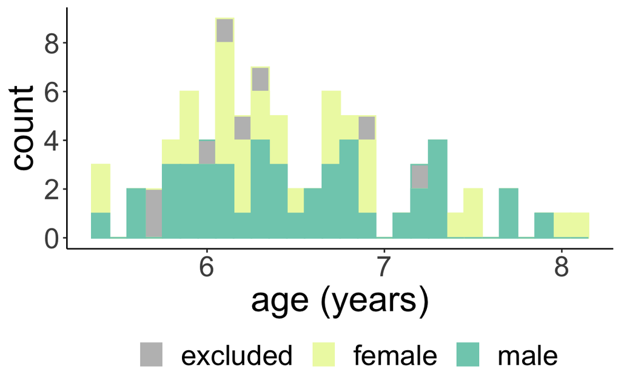

```r
# Time to plot!
demographics <- ggplot(data = qa_df %>% filter(bval == 1000)) +
  geom_histogram(aes(x = age, fill = 'excluded', colour = sex), binwidth = 0.1) +
  geom_histogram(data = df_restricted %>% filter(bval == 1000),
                 aes(x = age, fill = sex, colour = sex),binwidth = 0.1) +
  ylim(0,10) +
  theme_classic() +
  xlab("age (years)") +
  scale_fill_manual(values = c("Grey","#EDF8B1", "#7FCDBB")) +
  scale_color_brewer(palette = "YlGnBu") +
  guides(colour = "none") +
  theme(legend.title=element_blank()) +
  theme(legend.position = 'bottom') +
  theme(text = element_text(size = 25)) +
  scale_y_continuous(breaks=pretty_breaks())
plot(demographics)
ggsave('~/Documents/UofT/ResearchStuff/OutsideProject/Writeup/Figures/Demographics2.pdf', width=7,height=6)
```

Let’s take a look at a few things, just as a confidence check. I need a multi-shell measure of motion that’s averaged across both shells, and I’ll preemptively compute the log of this measure as well:

```r
df_restricted <- df_restricted %>% group_by(participant_id) %>%
  mutate(ms_motion = mean(meanRELrms_b0.1)) %>%
  mutate(log_ms_motion = log(ms_motion))
```

I’m actually also going to create a separate data frame for the multi-shell data to avoid accidentally duplicating all subjects in subsequent analyses.

```r
df_restricted_ms <- df_restricted %>% filter(bval == 1000) %>%
  ungroup() %>%
  select(-c(bval, meanABSrms_b1000, meanABSrms_b2000, meanABSrms_b0.1,
            meanRELrms_b1000, meanRELrms_b2000, meanRELrms_b0.1,
            tsnr_b0.1, tsnr_b1000, tsnr_b2000,
            mean, sd, zscore)) %>%
  select(-contains("_ss_"))
```

First I want to plot a histogram of our motion metric with and without log transforming it.

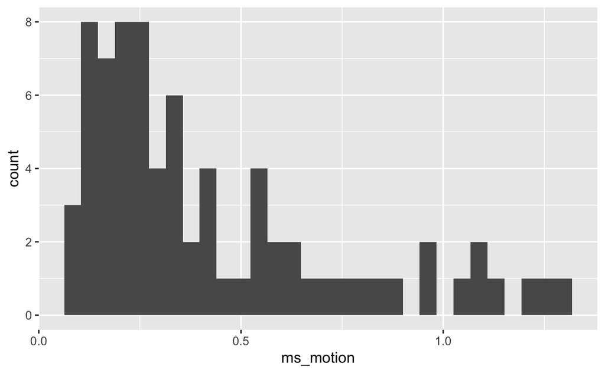

```r
ggplot(data = df_restricted_ms, aes(x = ms_motion)) +
  geom_histogram()
```

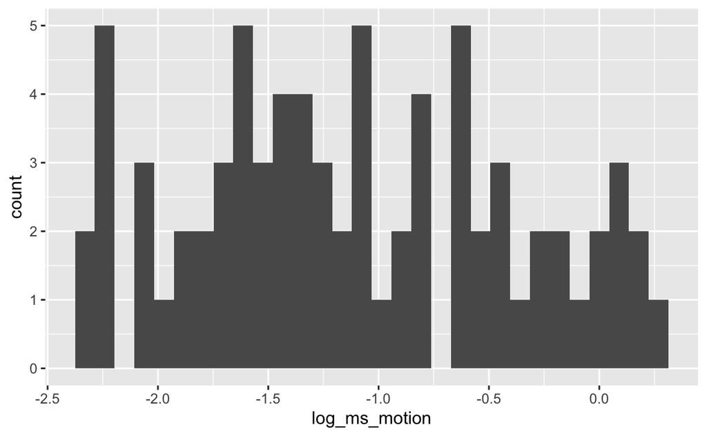

```r
ggplot(data = df_restricted_ms, aes(x = log_ms_motion)) +
  geom_histogram()
```

Clearly, log-transforming the motion data is a good option. I’m going to make this change for the single-shell data as well.

```r
df_restricted <- df_restricted %>%
  mutate(meanRELrms_b0.1_log = log(meanRELrms_b0.1))

# and create b=1000 and b=2000 dataframes to make my life easier
df_1000 <- df_restricted %>% filter(bval == 1000)
df_2000 <- df_restricted %>% filter(bval == 2000)
```

I’m also curious about how our various measures compare across pipelines and shells. I ran a bunch of correlations to see. I’ve suppressed this output because it’s not *that* interesting, but correlation across pipelines is worst for FA metrics, and single:double-shell comparisons within pipelines is pretty high. All correlations are above r=.5 and highly significant.

The next thing I wanted to assess is how log(motion) relates to age:

```r
cor.test(df_restricted_ms$log_ms_motion, df_restricted_ms$age) -> motion_age
motion_age
```

```
    Pearson's product-moment correlation

data:  df_restricted_ms$log_ms_motion and df_restricted_ms$age
t = -1.2561, df = 73, p-value = 0.2131
alternative hypothesis: true correlation is not equal to 0
95 percent confidence interval:
 -0.36051208  0.08429309
sample estimates:
       cor
-0.1454514
```

```r
cor.test(df_1000$meanRELrms_b0.1_log, df_1000$age)
```

```
    Pearson's product-moment correlation

data:  df_1000$meanRELrms_b0.1_log and df_1000$age
t = -1.1557, df = 73, p-value = 0.2516
alternative hypothesis: true correlation is not equal to 0
95 percent confidence interval:
 -0.35034776  0.09583282
sample estimates:
       cor
-0.1340445
```

```r
cor.test(df_2000$meanRELrms_b0.1_log, df_2000$age)
```

```
    Pearson's product-moment correlation

data:  df_2000$meanRELrms_b0.1_log and df_2000$age
t = -1.1025, df = 73, p-value = 0.2739
alternative hypothesis: true correlation is not equal to 0
95 percent confidence interval:
 -0.3449198  0.1019465
sample estimates:
       cor
-0.1279764
```

Overall, I’m not seeing anything super compelling for single- vs multi-shell. I’ll plot the multi-shell version.

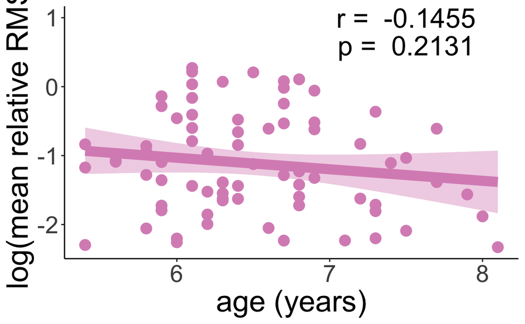

```r
ts=25
rel_rms_age <- ggplot() +
  geom_smooth(data = df_restricted %>% filter(bval == 2000),
              formula = y ~ x,
               aes(x = age, y = log_ms_motion), method = "lm",
               colour = "#da90c0", fill = "#da90c0", linewidth = 4) +
  geom_point(data = df_restricted %>% filter(bval == 2000),
              aes(x = age, y = log_ms_motion),
              colour = "#da90c0", fill = "#da90c0", size = 4) +
  theme_classic() +
  ylab('log(mean relative RMS)') +
  xlab("age (years)") +
  theme(legend.position = "none") +
  theme(text = element_text(size = ts)) +
  annotate("text", y=1, x=7.5, label = paste("r = ", round(motion_age$estimate,4)), size =
             (8)) + # PreQual
  annotate("text", y=.6, x=7.5, label= paste("p = ", round(motion_age$p.value,4)), size =
             (8))

plot(rel_rms_age)

ggsave('~/Documents/UofT/ResearchStuff/OutsideProject/Writeup/Figures/rms_age.pdf',
       rel_rms_age, width = 16, height = 12, units = 'cm', )
```

## Assessing the Impact of Motion

My next step was to use the approach in [Pines, 2020](https://www.ncbi.nlm.nih.gov/pmc/articles/PMC7200217/) to see if there was residual motion in the preprocessed data that related to different diffusion metrics. First, I’ll look at multi-shell data using the relative RMS displacement calculated from interspersed b0 values and averaged across the two shells and diffusion metrics calculated from a tensor fit to the multi-shell data.

I’ll fit a separate model for each diffusion metric (FA, MD, RD, AD) and each pipeline and plot a visualization of the correlation. I’ve just shown the code for QSI Prep MD; the rest is hidden but the plots are all displayed below.

```r
# QSI MD
# First regress out age and sex
md_gam_nrms_qsi<-gam(global_md_qsi_ms~s(age,k=3)+sex,data=df_restricted_ms)
# Now look at correlation of residuals with motion
df_restricted_ms$md_resid_nrms_qsi<-md_gam_nrms_qsi$residuals +
  mean(df_restricted_ms$global_md_qsi_ms)
cor_md_qsi <- cor.test(df_restricted_ms$log_ms_motion,df_restricted_ms$md_resid_nrms_qsi)
# And plot
qsi_md_plot <- ggplot(df_restricted_ms,aes(x=log_ms_motion,y=md_resid_nrms_qsi)) +
  geom_smooth(method = 'lm', colour=('#59b4c2'), fill = "#59b4c2", alpha = .3, lwd = 4) +
  geom_point(alpha = .5, colour=('#59b4c2'), fill = "#59b4c2", size = 4) +
  ylab(element_blank()) + xlab(element_blank()) +
  ggtitle("QSI Prep") +
  my_theme +
  annotate("text", y=.00072, x=-.25, label= paste("r = ", round(cor_md_qsi$estimate,4)),
           size = 8) +
  annotate("text", y=.00071, x=-.25, label= paste("p = ", round(cor_md_qsi$p.value,4)),
           size = 8) +
  scale_y_continuous(labels = scales::number_format(accuracy = 0.00001),
                     limits = c(.00070,.00080)) +
  my_theme
```

Plot all graphs:

```r
corrected_corr_grid <- arrangeGrob(pq_md_plot, qsi_md_plot, pq_rd_plot, qsi_rd_plot,
             pq_ad_plot, qsi_ad_plot, pq_fa_plot, qsi_fa_plot, nrow = 4)
ggsave('~/Documents/UofT/ResearchStuff/OutsideProject/Writeup/Figures/test.pdf',
       corrected_corr_grid, width = 40, height = 60, units = 'cm', limitsize = FALSE)
```

Et voila the completed plot:

[figure not shown]

## Looking at single-shell effects

Because I’m not really sure how the pipelines are doing, I’m following Mike’s suggestion to run a mixed-effects GAM model for each pipeline that considers the b=1000 and b=2000 shells independently. I have a very hazy understanding of what this means currently.

I’m going to start with a single-shell version of the analysis above (without pretty plots for now)

```r
# PQ
# MD
md_gam_nrms_pq_ss_1000<-gam(global_md_pq_ss_1000~s(age,k=3)+sex,data=df_1000)
df_1000$md_resid_nrms_pq_ss_1000<-md_gam_nrms_pq_ss_1000$residuals +
  mean(df_1000$global_md_pq_ss_1000)
cor_md_pq_ss_1000 <- cor.test(df_1000$meanRELrms_b0.1_log,df_1000$md_resid_nrms_pq_ss_1000)
cor_md_pq_ss_1000
# RD
rd_gam_nrms_pq_ss_1000<-gam(global_rd_pq_ss_1000~s(age,k=3)+sex,data=df_1000)
df_1000$rd_resid_nrms_pq_ss_1000<-rd_gam_nrms_pq_ss_1000$residuals +
  mean(df_1000$global_rd_pq_ss_1000)
cor_rd_pq_ss_1000 <- cor.test(df_1000$meanRELrms_b0.1_log,df_1000$rd_resid_nrms_pq_ss_1000)
cor_rd_pq_ss_1000
# AD
ad_gam_nrms_pq_ss_1000<-gam(global_ad_pq_ss_1000~s(age,k=3)+sex,data=df_1000)
df_1000$ad_resid_nrms_pq_ss_1000<-ad_gam_nrms_pq_ss_1000$residuals +
  mean(df_1000$global_ad_pq_ss_1000)
cor_ad_pq_ss_1000 <- cor.test(df_1000$meanRELrms_b0.1_log,df_1000$ad_resid_nrms_pq_ss_1000)
cor_ad_pq_ss_1000
# FA
fa_gam_nrms_pq_ss_1000<-gam(global_fa_pq_ss_1000~s(age,k=3)+sex,data=df_1000)
df_1000$fa_resid_nrms_pq_ss_1000<-fa_gam_nrms_pq_ss_1000$residuals +
  mean(df_1000$global_fa_pq_ss_1000)
cor_fa_pq_ss_1000 <- cor.test(df_1000$meanRELrms_b0.1_log,df_1000$fa_resid_nrms_pq_ss_1000)
cor_fa_pq_ss_1000

# QSI
# MD
md_gam_nrms_qsi_ss_1000<-gam(global_md_qsi_ss_1000~s(age,k=3)+sex,data=df_1000)
df_1000$md_resid_nrms_qsi_ss_1000<-md_gam_nrms_qsi_ss_1000$residuals +
  mean(df_1000$global_md_qsi_ss_1000)
cor_md_qsi_ss_1000 <- cor.test(df_1000$meanRELrms_b0.1_log,df_1000$md_resid_nrms_qsi_ss_1000)
cor_md_qsi_ss_1000
# RD
rd_gam_nrms_qsi_ss_1000<-gam(global_rd_qsi_ss_1000~s(age,k=3)+sex,data=df_1000)
df_1000$rd_resid_nrms_qsi_ss_1000<-rd_gam_nrms_qsi_ss_1000$residuals +
  mean(df_1000$global_rd_qsi_ss_1000)
cor_rd_qsi_ss_1000 <- cor.test(df_1000$meanRELrms_b0.1_log,df_1000$rd_resid_nrms_qsi_ss_1000)
cor_rd_qsi_ss_1000
# AD
ad_gam_nrms_qsi_ss_1000<-gam(global_ad_qsi_ss_1000~s(age,k=3)+sex,data=df_1000)
df_1000$ad_resid_nrms_qsi_ss_1000<-ad_gam_nrms_qsi_ss_1000$residuals +
  mean(df_1000$global_ad_qsi_ss_1000)
cor_ad_qsi_ss_1000 <- cor.test(df_1000$meanRELrms_b0.1_log,df_1000$ad_resid_nrms_qsi_ss_1000)
cor_ad_qsi_ss_1000
# FA
fa_gam_nrms_qsi_ss_1000<-gam(global_fa_qsi_ss_1000~s(age,k=3)+sex,data=df_1000)
df_1000$fa_resid_nrms_qsi_ss_1000<-fa_gam_nrms_qsi_ss_1000$residuals +
  mean(df_1000$global_fa_qsi_ss_1000)
cor_fa_qsi_ss_1000 <- cor.test(df_1000$meanRELrms_b0.1_log,df_1000$fa_resid_nrms_qsi_ss_1000)
cor_fa_qsi_ss_1000
```

[output not shown]

It seems the single-shell data tell the same story. Mike said something about how one of the pipelines may actually decorrelate age and motion. Which means… PreQual gets rid of the association between age and motion, whereas QSI Prep may just get rid of motion itself. This could be why we still see motion effects in the PQ data but see stronger age effects thereafter. However, let’s rerun my original GAMs and some nested version (???) to see what happens. And after, I’ll run these GAMs but with single-shell motion metrics and subject as a random effect to see if this changes things.

I’ll actually start with the GAMs I fit for my original poster for completeness. Here I’m fitting two models to the data, with and without age, and seeing if adding age improves model fit by comparing with a chi-square anova.

```r
anova(ad_gam_pq_nage, ad_gam_pq_age, test = "Chisq")
```

```
Analysis of Deviance Table

Model 1: global_ad_pq_ms ~ sex + log_ms_motion
Model 2: global_ad_pq_ms ~ s(age, k = 3) + sex + log_ms_motion
  Resid. Df Resid. Dev Df   Deviance Pr(>Chi)
1        72 3.6752e-08
2        71 3.4338e-08  1 2.4139e-09  0.02548 *
---
Signif. codes:  0 ‘***’ 0.001 ‘**’ 0.01 ‘*’ 0.05 ‘.’ 0.1 ‘ ’ 1
```

The results here are similar to before… For QSI Prep, including age leads to marginally better model fits for md and ad, but with no significant effects of age.

For PreQual, including age leads to a marginally better model for MD but with no significant effect of age, but including age leads to a significantly better model fit for AD, with a significant effect of age and motion. Is it weird that including age increases the significance of the motion effect?

Let’s delve into a mixed-effects GAM. I’m going to combine the two single-shell dfs into one first.

```r
# Get rid of extra columns and rename so b1000 and b2000 are the same
df_1000 <- df_1000 %>% select(-contains("_ms")) %>%
  select(-contains("2000")) %>%
  select(-contains("resid"))
for (col in 1:ncol(df_1000)){
    colnames(df_1000)[col] <-  sub("_b1000", "", colnames(df_1000)[col])
    colnames(df_1000)[col] <-  sub("_1000", "", colnames(df_1000)[col])
}

df_2000 <- df_2000 %>% select(-contains("_ms")) %>%
  select(-contains("1000")) %>%
  select(-contains("resid"))
for (col in 1:ncol(df_2000)){
    colnames(df_2000)[col] <-  sub("_b2000", "", colnames(df_2000)[col])
    colnames(df_2000)[col] <-  sub("_2000", "", colnames(df_2000)[col])
}
# Stack !
df_ss <- rbind(df_1000, df_2000)
df_ss$participant_id<-gsub("cIVs","",as.character(df_ss$participant_id))

# Shortened some variable names when I was debugging

df_ss <- df_ss %>% rename(md_qsi = global_md_qsi_ss,
                          rd_qsi = global_rd_qsi_ss,
                          ad_qsi = global_ad_qsi_ss,
                          fa_qsi = global_fa_qsi_ss,
                          md_pq = global_md_pq_ss,
                          rd_pq = global_rd_pq_ss,
                          ad_pq = global_ad_pq_ss,
                          fa_pq = global_fa_pq_ss)
df_ss <- df_ss %>% rename(pid = participant_id)

df_ss$pid <- as.factor(df_ss$pid)
df_ss$bval <- as.factor(df_ss$bval)
```

My understanding of multi-level GAMs isn’t great, but I followed the example [here](https://bookdown.org/roback/bookdown-BeyondMLR/ch-lon.html#finalmodel) to some extent. I wanted my random effect to be (bval|participant), but I don’t have enough observations per participant (I think? the model wouldn’t run…).

```r
pq_md_ss_a <- gamm4(md_pq ~ bval + sex + s(age) + meanRELrms_b0.1_log,
                      data = df_ss, random =~ (1|pid))
pq_md_ss_na <- gamm4(md_pq ~ bval + sex + meanRELrms_b0.1_log,
                       data = df_ss, random =~ (1|pid))
anova(pq_md_ss_a$mer, pq_md_ss_na$mer, test = "Chisq")
```

```
refitting model(s) with ML (instead of REML)
```

```
Data: NULL
Models:
pq_md_ss_na$mer: NULL
pq_md_ss_a$mer: NULL
                npar     AIC     BIC logLik deviance  Chisq Df Pr(>Chisq)
pq_md_ss_na$mer    6 -2917.7 -2899.6 1464.8  -2929.7
pq_md_ss_a$mer     8 -2918.5 -2894.5 1467.3  -2934.5 4.8816  2    0.08709 .
---
Signif. codes:  0 ‘***’ 0.001 ‘**’ 0.01 ‘*’ 0.05 ‘.’ 0.1 ‘ ’ 1
```

```r
pq_rd_ss_a <- gamm4(rd_pq ~ bval + s(age) + sex + meanRELrms_b0.1_log,
                      data = df_ss, random =~ (1|pid))
pq_rd_ss_na <- gamm4(rd_pq ~ bval + sex + meanRELrms_b0.1_log,
                       data = df_ss, random =~ (1|pid))
anova(pq_rd_ss_a$mer, pq_rd_ss_na$mer, test = "Chisq")
```

```
refitting model(s) with ML (instead of REML)
```

```
Data: NULL
Models:
pq_rd_ss_na$mer: NULL
pq_rd_ss_a$mer: NULL
                npar     AIC     BIC logLik deviance  Chisq Df Pr(>Chisq)
pq_rd_ss_na$mer    6 -2900.7 -2882.7 1456.4  -2912.7
pq_rd_ss_a$mer     8 -2899.8 -2875.7 1457.9  -2915.8 3.0502  2     0.2176
```

```r
pq_ad_ss_a <- gamm4(ad_pq ~ bval + s(age) + sex + meanRELrms_b0.1_log,
                      data = df_ss, random =~ (1|pid))
pq_ad_ss_na <- gamm4(ad_pq ~ bval + sex + meanRELrms_b0.1_log,
                       data = df_ss, random =~ (1|pid))
anova(pq_ad_ss_a$mer, pq_ad_ss_na$mer, test = "Chisq")
```

```
refitting model(s) with ML (instead of REML)
```

```
Data: NULL
Models:
pq_ad_ss_na$mer: NULL
pq_ad_ss_a$mer: NULL
                npar     AIC     BIC logLik deviance  Chisq Df Pr(>Chisq)
pq_ad_ss_na$mer    6 -2887.3 -2869.3 1449.7  -2899.3
pq_ad_ss_a$mer     8 -2890.4 -2866.3 1453.2  -2906.4 7.0566  2    0.02935 *
---
Signif. codes:  0 ‘***’ 0.001 ‘**’ 0.01 ‘*’ 0.05 ‘.’ 0.1 ‘ ’ 1
```

```r
pq_fa_ss_a <- gamm4(fa_pq ~ bval + s(age) + sex + meanRELrms_b0.1_log,
                      data = df_ss, random =~ (1|pid))
pq_fa_ss_na <- gamm4(fa_pq ~ bval + sex + meanRELrms_b0.1_log,
                       data = df_ss, random =~ (1|pid))
anova(pq_fa_ss_a$mer, pq_fa_ss_na$mer, test = "Chisq")
```

```
refitting model(s) with ML (instead of REML)
```

```
Data: NULL
Models:
pq_fa_ss_na$mer: NULL
pq_fa_ss_a$mer: NULL
                npar     AIC     BIC logLik deviance  Chisq Df Pr(>Chisq)
pq_fa_ss_na$mer    6 -1006.3 -988.25 509.16  -1018.3
pq_fa_ss_a$mer     8 -1003.4 -979.35 509.72  -1019.4 1.1184  2     0.5717
```

```r
# QSI
qsi_md_ss_a <- gamm4(md_qsi ~ bval + s(age) + sex + meanRELrms_b0.1_log,
                      data = df_ss, random =~ (1|pid))
qsi_md_ss_na <- gamm4(md_qsi ~ bval + sex + meanRELrms_b0.1_log,
                       data = df_ss, random =~ (1|pid))
anova(qsi_md_ss_a$mer, qsi_md_ss_na$mer, test = "Chisq")
```

```
refitting model(s) with ML (instead of REML)
```

```
Data: NULL
Models:
qsi_md_ss_na$mer: NULL
qsi_md_ss_a$mer: NULL
                 npar     AIC     BIC logLik deviance  Chisq Df Pr(>Chisq)
qsi_md_ss_na$mer    6 -2851.3 -2833.2 1431.7  -2863.3
qsi_md_ss_a$mer     8 -2850.8 -2826.7 1433.4  -2866.8 3.4454  2     0.1786
```

```r
qsi_rd_ss_a <- gamm4(rd_qsi ~ bval + s(age) + sex + meanRELrms_b0.1_log,
                      data = df_ss, random =~ (1|pid))
qsi_rd_ss_na <- gamm4(rd_qsi ~ bval + sex + meanRELrms_b0.1_log,
                       data = df_ss, random =~ (1|pid))
anova(qsi_rd_ss_a$mer, qsi_rd_ss_na$mer, test = "Chisq")
```

```
refitting model(s) with ML (instead of REML)
```

```
Data: NULL
Models:
qsi_rd_ss_na$mer: NULL
qsi_rd_ss_a$mer: NULL
                 npar     AIC     BIC logLik deviance  Chisq Df Pr(>Chisq)
qsi_rd_ss_na$mer    6 -2829.3 -2811.2 1420.7  -2841.3
qsi_rd_ss_a$mer     8 -2826.8 -2802.7 1421.4  -2842.8 1.4758  2     0.4781
```

```r
qsi_ad_ss_a <- gamm4(ad_qsi ~ bval + s(age) + sex + meanRELrms_b0.1_log,
                      data = df_ss, random =~ (1|pid))
qsi_ad_ss_na <- gamm4(ad_qsi ~ bval + sex + meanRELrms_b0.1_log,
                       data = df_ss, random =~ (1|pid))
anova(qsi_ad_ss_a$mer, qsi_ad_ss_na$mer, test = "Chisq")
```

```
refitting model(s) with ML (instead of REML)
```

```
Data: NULL
Models:
qsi_ad_ss_na$mer: NULL
qsi_ad_ss_a$mer: NULL
                 npar     AIC     BIC logLik deviance  Chisq Df Pr(>Chisq)
qsi_ad_ss_na$mer    6 -2792.5 -2774.5 1402.3  -2804.5
qsi_ad_ss_a$mer     8 -2792.8 -2768.8 1404.4  -2808.8 4.3075  2      0.116
```

```r
qsi_fa_ss_a <- gamm4(fa_qsi ~ bval + s(age) + sex + meanRELrms_b0.1_log,
                      data = df_ss, random =~ (1|pid))
qsi_fa_ss_na <- gamm4(fa_qsi ~ bval + sex + meanRELrms_b0.1_log,
                       data = df_ss, random =~ (1|pid))
anova(qsi_fa_ss_a$mer, qsi_fa_ss_na$mer, test = "Chisq")
```

```
refitting model(s) with ML (instead of REML)
```

```
Data: NULL
Models:
qsi_fa_ss_na$mer: NULL
qsi_fa_ss_a$mer: NULL
                 npar     AIC     BIC logLik deviance  Chisq Df Pr(>Chisq)
qsi_fa_ss_na$mer    6 -910.30 -892.24 461.15  -922.30
qsi_fa_ss_a$mer     8 -906.37 -882.29 461.19  -922.37 0.0665  2     0.9673
```

General conclusion is that fitting with single-shell data leads to the same results as fitting with multi-shell data. Which would mean that our final conclusion is that both pipelines are similar, but PreQual may have a slight edge at dissociating age and motion (if we want to go with that narrative). BUT is it also possible that because motion and age are related, that’s what we’re picking up in the PreQual data?